# R markdown

Hevar

2025-02-18

## First Set of questions

Reading the date and making adjustments

```r
df <- read.csv('activity.csv')
df$date <- as.Date(df$date)
str(df)
```

```
## 'data.frame':    17568 obs. of  3 variables:
##  $ steps   : int  NA NA NA NA NA NA NA NA NA NA ...
##  $ date    : Date, format: "2012-10-01" "2012-10-01" ...
##  $ interval: int  0 5 10 15 20 25 30 35 40 45 ...
```

```r
colSums(is.na(df))
```

```
##    steps     date interval
##     2304        0        0
```

Calculate the total number of steps taken per day

```r
step_sum <- tapply(df$steps, df$date, sum, na.rm = T)
sum_data <- as.data.frame(step_sum)
sum_data$dates <- rownames(sum_data)
head(sum_data)
```

```
##            step_sum      dates
## 2012-10-01        0 2012-10-01
## 2012-10-02      126 2012-10-02
## 2012-10-03    11352 2012-10-03
## 2012-10-04    12116 2012-10-04
## 2012-10-05    13294 2012-10-05
## 2012-10-06    15420 2012-10-06
```

Creating the histogram

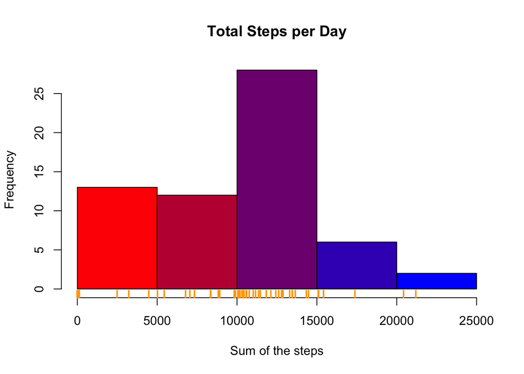

```r
colors <- colorRampPalette(c('red', 'blue'))
color <- colors(5)
hist(sum_data$step_sum,col = color, xlab = 'Sum of the steps',
        main = 'Total Steps per Day')
rug(sum_data$step_sum, lwd = 2, lty = 1, col = 'orange')
```

Calculating the mean and median for the total steps per day

```r
mean_value <- mean(sum_data$step_sum, na.rm = T)
median_value <- median(sum_data$step_sum, na.rm = T)
print(paste('The mean value of the total steps is :' ,round(mean_value, 2)))
```

```
## [1] "The mean value of the total steps is : 9354.23"
```

```r
print(paste('The median value of the total steps is :' ,median_value))
```

```
## [1] "The median value of the total steps is : 10395"
```

## Second Set Of Questions

What is the average daily activity pattern?

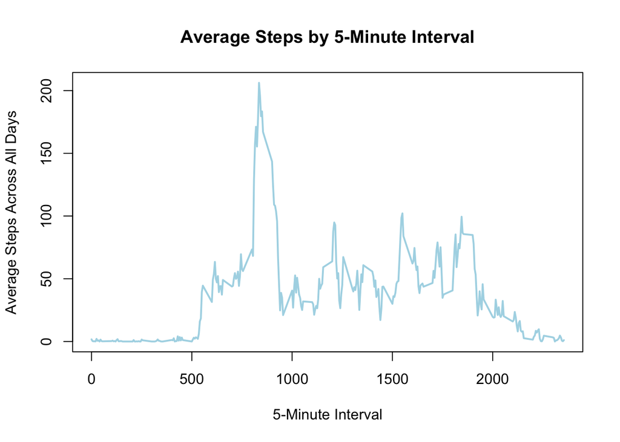

```r
second_df <- df # this was done to avoid messing with the original data
interval_avg_steps <- aggregate(steps ~ interval, data = second_df,
        FUN = mean, na.rm = TRUE)
plot(interval_avg_steps$interval, interval_avg_steps$steps,
        type = "l",
        xlab = "5-Minute Interval",
        ylab = "Average Steps Across All Days",
        main = "Average Steps by 5-Minute Interval",
        col = "lightblue", lwd = 2)
```

which 5 minute interval contain the highest number of steps

```r
print(paste('The maxium number of total steps is in interval:',
        interval_avg_steps[max(interval_avg_steps$steps),]$interval))
```

[output not shown]

## The Third Set Of Questions

To deal with the missing values in the data, means of the intervals were used.

```r
table(rowSums(is.na(df))) # one means the row contains NA values
```

```
##
##     0     1
## 15264  2304
```

```r
third_df <- df # Again this was done to avoid messing with original data

mean_values <- aggregate(third_df$steps~third_df$interval, FUN = mean, na.rm = T)
colnames(mean_values) <- c('interval','means')

clean_data <- merge(third_df, mean_values, by.x= 'interval', by.y = 'interval')
clean_data$steps <- ifelse(is.na(clean_data$steps),
        clean_data$means, clean_data$steps)
clean_data$means<- NULL
clean_data$steps <- round(clean_data$steps, 2)
```

Calculating the total amount of steps per day

```r
total_steps_clean <- tapply(clean_data$steps, clean_data$date, sum)
total_steps_clean <- as.data.frame(total_steps_clean)
```

Compression of the plots before and after

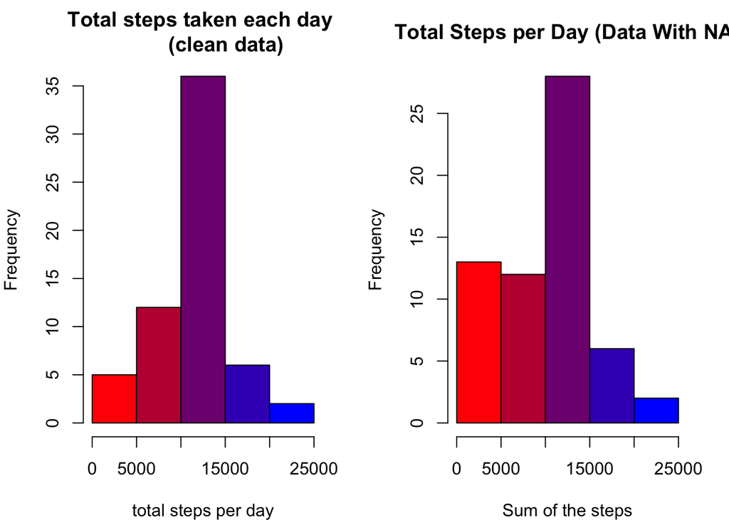

```r
par(mfcol = c(1,2), mar = c(4,4,3,2))
hist(total_steps_clean$total_steps_clean, col = color,
        xlab = 'total steps per day', main = 'Total steps taken each day
        (clean data)')
hist(sum_data$step_sum,col = color, xlab = 'Sum of the steps',
        main = 'Total Steps per Day (Data With NA)')
```

difference between the mean and median values after the data was cleaned

```r
clean_mean <- mean(total_steps_clean$total_steps_clean)
clean_median <- median(total_steps_clean$total_steps_clean)

print(paste('The mean value after cleaning the data is:' ,
        round(clean_mean,2), 'before it was:', round(mean_value,2)))
```

```
## [1] "The mean value after cleaning the data is: 10766.18 before it was: 9354.23"
```

```r
print(paste('The median value after cleaning the data is:' ,
        round(clean_median,2), 'before it was:',round(median_value,2)))
```

```
## [1] "The median value after cleaning the data is: 10766.13 before it was: 10395"
```

After cleaning the data by imputing missing values, the mean number of steps per day increased from 9354.23 to 10766.18, and the median number of steps per day rose from 10395 to 10766.13. This suggests that imputing the missing values with the interval mean resulted in a slight upward shift in the overall daily step counts.

## Last Set Of Questions

Creating the weekends columns, this column is used to compare the total steps in the weekends and the weekdays.

```r
library(lubridate)
clean_data$weekday <- wday(clean_data$date, label = T)

clean_data$weekday <- ifelse(clean_data$weekday == 'Sat'
        | clean_data$weekday == 'Sun', 'weekends', 'weekdays')
```

Creating the plots please be aware that this plot differs from the instructor plot, due to difference in the data as mentioned by the instructor.

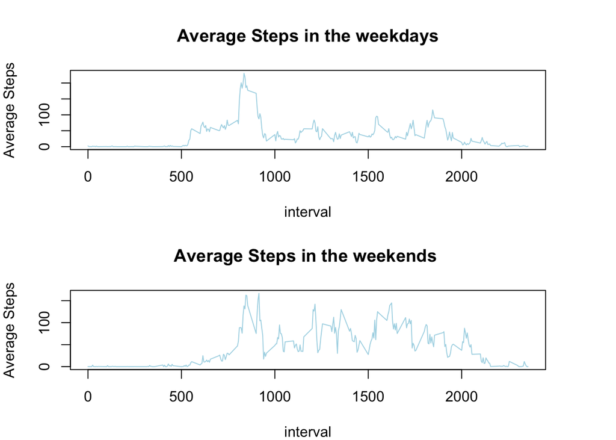

```r
clean_data$weekday <- as.factor(clean_data$weekday)
Average_steps <- aggregate(clean_data$steps~clean_data$interval+clean_data$weekday, FUN = mean)
colnames(Average_steps) <- c('interval', 'weekday', 'Average_steps')
par(mfrow = c(2,1), mar = c(4,4,4,4))
with(subset(Average_steps, weekday == 'weekdays'), plot( interval, Average_steps,
        col = 'lightblue', type = 'l',
        xlab = 'interval',
        ylab = 'Average Steps',
        main = 'Average Steps in the weekdays'))
with(subset(Average_steps, weekday == 'weekends'), plot( interval, Average_steps,
        col = 'lightblue', type = 'l',
        xlab = 'interval',
        ylab = 'Average Steps',
        main = 'Average Steps in the weekends '))
```